HUIJZER.XYZ

# Increasing model accuracy by using foreknowledge

2021-06-16

Typically, when making predictions via a linear model, we fit the model on our data and make predictions from the fitted model. However, this doesn't take much foreknowledge into account. For example, when predicting a person's length given only the weight and gender, we already have an intuition about the effect size and direction. Bayesian analysis should be able to incorporate this prior information.

```julia
begin
	using AlgebraOfGraphics
	using CairoMakie
	using CategoricalArrays
	using DataFrames
	using GLM
	using MLDataUtils: rescale!
	using Random: seed!
	using Statistics
	using StatsFuns
	using Turing
end
```

We generate data for $n$ individuals via:

```julia
function generate_data(i::Int)
  seed!(i)

  n = 120
  I = 1:n
  P = [i % 2 == 0 for i in I]
  r_2(x) = round(x; digits=2)

  A = r_2.([p ? rand(Normal(aₑ * 18, 1)) : rand(Normal(18, 1)) for p in P])
  R = r_2.([p ? rand(Normal(rₑ * 6, 3)) : rand(Normal(6, 3)) for p in P])
  E = r_2.(rand(Normal(0, 1), n))
  G = aₑ .* A + rₑ .* R .+ E
  G = r_2.(G)

  df = DataFrame(age=A, recent=R, error=E, grade=G, pass=P)
end;
```

```julia
df = generate_data(1)
```

| age | recent | error | grade | pass |
| --- | --- | --- | --- | --- |
| 18.3 | 2.26 | -0.74 | 21.76 | false |
| 20.18 | 2.31 | 1.14 | 25.76 | true |
| 17.4 | 1.92 | -0.9 | 20.26 | false |
| 19.79 | 7.93 | 0.02 | 30.12 | true |
| 17.16 | -1.9 | -1.55 | 15.33 | false |
| 20.11 | 6.75 | 0.19 | 29.4 | true |
| 20.3 | 1.02 | 0.92 | 24.32 | false |
| 17.53 | -1.95 | 0.16 | 17.4 | true |
| 18.53 | 4.75 | 0.26 | 25.63 | false |
| 20.23 | 2.01 | -2.62 | 21.74 | true |
| ... |  |  |  |  |
| 20.31 | 4.32 | 0.26 | 27.14 | true |

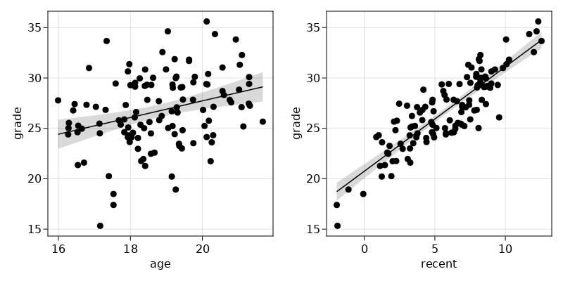

## Linear regression

First, we fit a linear model and verify that the coefficients are estimated reasonably well. Here, the only prior information that we give the model is the structure of the data, that is, a formula.

```julia
linear_model = lm(@formula(grade ~ age + recent), df)
```

```
StatsModels.TableRegressionModel{LinearModel{GLM.LmResp{Vector{Float64}}, GLM.DensePredChol{Float64, LinearAlgebra.CholeskyPivoted{Float64, Matrix{Float64}}}}, Matrix{Float64}}

grade ~ 1 + age + recent

Coefficients:
───────────────────────────────────────────────────────────────────────
               Coef.  Std. Error      t  Pr(>|t|)  Lower 95%  Upper 95%
───────────────────────────────────────────────────────────────────────
(Intercept)  0.85718   1.44699     0.59    0.5547  -2.00851     3.72287
age          1.0436    0.0750508  13.91    <1e-25   0.894965    1.19223
recent       1.07894   0.0337224  31.99    <1e-58   1.01216     1.14573
───────────────────────────────────────────────────────────────────────
```

```julia
r5(x) = round(x; digits=5)
```

```
r5 (generic function with 1 method)
```

```julia
coefa = coef(linear_model)[2] |> r5
```

```
1.0436
```

```julia
coefr = coef(linear_model)[3] |> r5
```

```
1.07894
```

Notice how these estimated coefficients are close to the coefficients that we set for `age` and `recent`, namely a_e = 1.1 ≈ 1.0436 and r_e = 1.05 ≈ 1.07894, as expected.

## Bayesian regression

For the Bayesian regression we fit a model via Turing.jl. Now, we give the model information about the structure of the data as well as priors for the size of the coefficients. For demonstration purposes, I've set the priors to the correct values. This is reasonable because I was wondering whether finding a good prior could have a positive effect on the model accuracy.

```julia
function rescale_data(df)
    out = DataFrame(df)
    rescale!(out, [:age, :recent, :grade])
    out
end;
```

```julia
rescaled = let
	rescaled = rescale_data(df)
	rescaled[!, :pass_num] = [p ? 1.0 : 0.0 for p in rescaled.pass]
end;
```

```julia
@model function bayesian_model(ages, recents, grades, n)
    intercept ~ Normal(0, 5)
    βₐ ~ Normal(aₑ, 1)
    βᵣ ~ Normal(rₑ, 3)
    σ ~ truncated(Cauchy(0, 2), 0, Inf)

    μ = intercept .+ βₐ * ages .+ βᵣ * recents
    grades ~ MvNormal(μ, σ)
end;
```

```julia
chns = let
	n = nrow(df)
	bm = bayesian_model(df.age, df.recent, df.grade, n)
	chns = Turing.sample(bm, NUTS(), MCMCThreads(), 10_000, 3)
end;
```

Let's plot the density for the coefficient estimates $\beta_a$ and $\beta_r$:

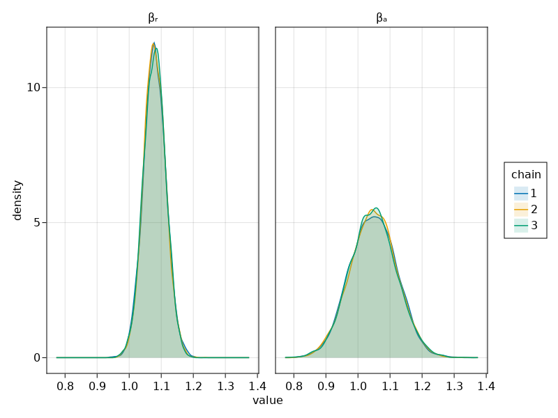

and compare the outputs from both models:

| coefficient | true value | linear estimate | linear error | bayesian estimate | bayesian error |
| --- | --- | --- | --- | --- | --- |
| aₑ | 1.1 | 1.0436 | 5.1 % | 1.04797852874484 | 4.7 % |
| rₑ | 1.05 | 1.07894 | 2.8 % | 1.079329686320674 | 2.8 % |

## Conclusion

After giving the true coefficients to the Bayesian model in the form of priors, it does score better than the linear model. However, the differences aren't very big. This could be due to the particular random noise in this sample `E` or due to the relatively big sample size. The more samples, the more likely it is that the data will overrule the prior. In any way, there are real-world situations where gathering extra data is more expensive than gathering priors via reading papers. In those cases, the increased accuracy introduced by using priors could have serious benefits.

*This blog post was built via a Pluto.jl notebook*.

[CC BY-SA 4.0](http://creativecommons.org/licenses/by-sa/4.0/) Rik Huijzer. Website built with Franklin.jl and the [Julia programming language](https://julialang.org). Last update: 2021-11-17.